# Predictors of prevalent dental caries in Chile using machine learning

Python reanalysis of ENS 2016–17

## 1 Structured summary

Five composite figures, with four to six panels each, preserve the original manuscript’s model-comparison bars and blue predictor-importance bars. The main importance figure now displays all 27 predictors, including water, in six panels with a common axis. Updated descriptive tables retain the original no-caries/caries/total comparison and add survey-weighted uncertainty and explicit missingness.

**Question.** How do the 27 demographic, dental and dietary predictors contribute to classification of existing cavitated caries, and how stable are their contributions across held-out survey clusters and model families?

**5,036**Dentate participants in model development

**27**Predictors evaluated in both importance analyses

**54.6%**Survey-weighted prevalence of cavitated caries

**Design.** This cross-sectional reanalysis included 5,036 dentate ENS participants aged 15 years or older, with one held-out probability per model from 5-fold outer and 3-fold inner cluster-grouped validation. Raw-variable permutation importance and fold stability are reported for every predictor in random forest and spline logistic regression. Joint permutation also evaluates conceptually defined predictor blocks. Classification performance provides context for interpreting these contributions.

**Findings.** The three largest mean held-out Brier-score increases were **Random forest:** Remaining teeth (ΔBrier 0.0044), Age (ΔBrier 0.0032), Sex (ΔBrier 0.0014); **Spline logistic regression:** Remaining teeth (ΔBrier 0.0044), Age (ΔBrier 0.0043), Sex (ΔBrier 0.0007). The highest full-feature AUC was 0.606; the importance results must be read in that performance context.

**Interpretation.** Importance describes the contribution to a particular fitted classifier, with uncertainty reflected by fold-to-fold stability. It does not identify causes, exposure-effect directions or a uniquely correct predictor ranking. Water was an emerging result of interest and is examined in a secondary exploratory section; it was not the primary scientific objective.

## 2 Scope, provenance and study population

This report evaluates contributions of all measured predictor constructs to current caries classification, using the original data and an audited R reference in the [ENS-dental-caries repository](https://github.com/AmaruSimonAgueroJimenez/ENS-dental-caries/tree/77c107feb56d3f825cd4ad26354b672f8bfebe38). The original `docs/index.qmd` and saved HTML are preserved; the HTML contains the manuscript’s reported AUC values. Those saved results identify the reference analysis but are not newly rerun R estimates.

The original Stata attachment was recovered from Andrea Correa’s email of 31 July 2023 and reconciled by survey identifier with the supplementary SPSS release. SPSS supplies survey weights, PSUs and additional water-context fields absent from the original Stata file. This is a **Python reanalysis with verified original data**. The analysis plan and R-to-Python audit explain the intentional methodological changes; identical historical `caret` metrics are not an objective.

Source verification. Original Stata input and supplementary SPSS release.

| Source check | Verified result |
| --- | --- |
| Original Stata participants matched by identifier | 5,520 |
| Unmatched original participants | 0 |
| Caries / decayed-teeth / remaining-teeth discrepancies | 0 / 0 / 0 |
| Predictors matching before beverage-month harmonization | 25 / 27 |
| Predictors matching after documented harmonization | 27 / 27 |
| Unexplained predictor discrepancies | 0 |

Source rows occur in different orders, so checks join by survey identifier. Decoded education and indigenous identification agree. Aggregate checks contain no participant identifiers; both file hashes appear in the reproducibility record.

The recovered water values and R source show that the later Quarto expression converts labelled water values to **factor indices**, preserving order but changing cardinal spacing. Earlier R scripts leave water as a factor. For example, 40 reported glasses/day becomes index 25. The Python analysis retains the reported numeric glasses/day. These are codes for individual observed quantities, not documented low/medium/high intake groups. A separate controlled encoding sensitivity is reported below. Questionnaire-conditional and original unconditional skip recoding happen to give identical values in this observed dataset; the revised rules explicitly distinguish structural non-consumption from nonresponse.

The original R program uses an individual-level training/test partition with internal cross-validation and omits survey fitting weights and PSU grouping. The Python analysis groups survey clusters, uses weights where supported and learns statistical preprocessing within training folds. These are substantive changes to development and evaluation, so historical AUCs should not be compared as if they arose from the same validation experiment.

The newly recovered original materials confirm a requested change from categorical to numeric water on 24 September 2024. The preserved implementation converts factor levels to numerical indices. Water bands were proposed on 22 November, after the October importance spreadsheet; no implementation or output using those bands was found. The dietary supplement presents water as mean (standard deviation), which establishes its descriptive presentation, not the representation supplied to every historical algorithm.

The original Word chart matches all 11 leading scores in the recovered spreadsheet exactly: water is third, at 53.9819 on a rescaled 0–100 scale. The spreadsheet ranks 90 encoded terms representing 27 predictors, including seven single numeric columns and 83 category indicators. Later October/November discussions explicitly intend mean decrease in accuracy, superseding earlier Gini terminology. However, the preserved QMD omits `importance=TRUE`; archived caret 6.0-94 defaults and the recovered single-column `Overall` cache strongly support rescaled Gini under that code. The fitted forest and raw importance matrix remain unavailable, so the exact runtime metric cannot be certified. This separates the documented intention from implementation evidence. [randomForest fitting documentation](https://search.r-project.org/CRAN/refmans/randomForest/html/randomForest.html).

These historical scores are not directly comparable with the revised held-out, unscaled Brier-score permutation importance of whole original predictors. The historical analysis audit documents the source matches, chronology, metric discrepancy and an original legume-category translation error. The subsequent matched-coding refits are reported below as a separate post hoc extension.

ENS is a cross-sectional, stratified, multistage survey. Published documentation describes an oral examination by trained nurses during the second home visit. Eligibility in other oral-health publications differs from the present dentate domain and should not be imposed on this analysis. [Margozzini et al., 2020](https://pmc.ncbi.nlm.nih.gov/articles/PMC7479467/)

Table 1. Population flow and manuscript reconstruction.

| Stage | Participants |
| --- | --- |
| Supplied survey records | 6,233 |
| No complete oral examination | 713 |
| Complete oral examination | 5,520 |
| Excluded: completely edentulous | 484 |
| Primary dentate prediction cohort | 5,036 |
| Participants with cavitated caries | 2,689 |
| Missing education within the dentate cohort | 38 |
| Missing water within the dentate cohort | 4 |
| Education-and-water-complete manuscript subset | 4,994 |
| Caries cases in the manuscript subset | 2,664 |

Rows showing cases and missing predictors describe nested groups, not additional sequential exclusions. No outcomes were imputed.

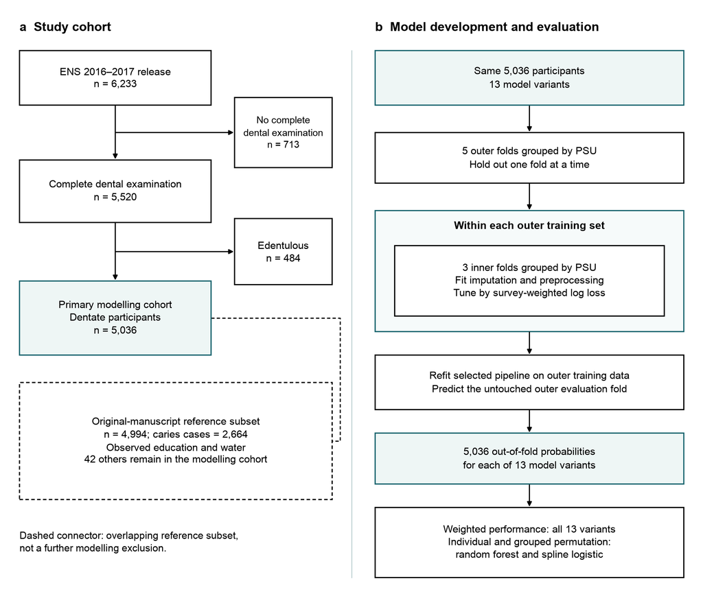

Study cohort and nested validation. Panel a distinguishes the primary dentate modelling cohort from the overlapping original-manuscript reference subset, which requires observed education and water. Participants outside that reference subset remain eligible for modelling. Panel b shows training-only preprocessing and tuning with PSU-disjoint folds. Each participant receives one out-of-fold probability per fitted model variant. Survey-weighted performance is evaluated for all variants; individual and joint-group permutation analyses use random forest and spline logistic regression. ENS, Chilean National Health Survey; PSU, primary sampling unit.

The primary prediction cohort retains **5,036** participants through training-fold imputation. The exact manuscript subset has **4,994** participants with observed education and water. Weighted caries prevalence was **54.6 (51.9 to 57.3)%**, compared with **53.4%** unweighted. Design-based intervals use 1,045 degrees of freedom.

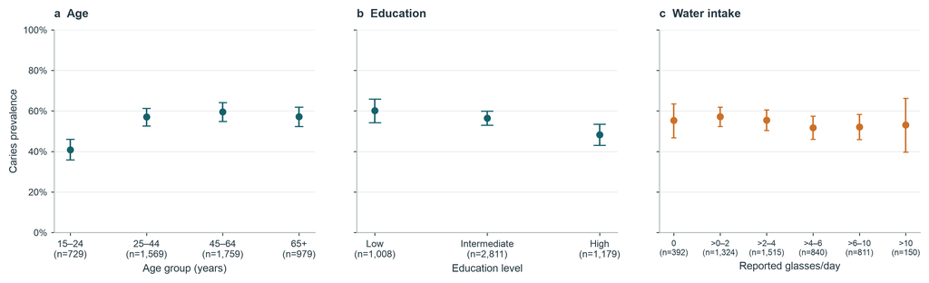

Survey-weighted caries prevalence by age, education, and reported water intake, with 95% survey-design confidence intervals. Parentheses give unweighted group sample sizes. These are unadjusted descriptive comparisons among dentate participants; group differences must not be interpreted as causal effects.

The outcome is at least one currently decayed permanent tooth, obtained from valid upper- and lower-jaw counts and verified against the original Stata outcome. Completely edentulous people are outside this target population. This measure is neither DMFT nor incident disease; participants without current decay can have substantial prior dental disease or tooth loss. Remaining teeth is a concurrent dental measure, potentially affecting both opportunity to observe decay and model performance.

## 3 Exposures, predictors and data quality

The full comparison uses eight demographic/dental predictors and 19 dietary constructs. Water is self-reported glasses/day. Available metadata do not establish glass volume, fluoride concentration, individual fluoride exposure or substitution for sugary drinks. The three-variable extension adds household supply, recent rural/well/spring water use and dental attendance. These are available contextual variables, but household supply need not be the source of each glass, and attendance may follow disease.

**Demographic/dental block:** Age at survey; Recorded sex; Survey region (2016 boundaries); Urban/rural residence; Low <8, intermediate 8–12, high >=13 years of schooling; Self-reported membership/ancestry of a recognized indigenous people; Born in Chile; Total remaining teeth, upper plus lower jaw.

Table 2. The 19 dietary predictors in the full models.

| Dietary construct | Unit / coding |
| --- | --- |
| Fish/seafood consumption frequency | category |
| Dairy consumption frequency | category |
| Usual dairy fat content, with structural category for nonconsumers | category |
| Wholegrain consumption frequency | category |
| Legume consumption frequency | category |
| Fruit consumption days in a typical week | days/week |
| Fruit portions on a consumption day; zero for nonconsumers | portions/consumption day |
| Vegetable consumption days in a typical week | days/week |
| Vegetable portions on a consumption day; zero for nonconsumers | portions/consumption day |
| Frequency of checking/considering package ingredients | category |
| Frequency of checking/considering package nutrition | category |
| Frequency of checking/considering package warnings | category |
| Frequency of checking/considering package health | category |
| Frequency of checking/considering package brand | category |
| Frequency of checking/considering package discounts | category |
| Self-reported glasses of water per day; water source/fluoride exposure not identified | glasses/day |
| Sugar-sweetened soda consumption frequency converted to times/day | times/day |
| Sugar-sweetened juice consumption frequency converted to times/day | times/day |
| Most frequently used cooking oil/fat | category |

Fruit and vegetable portions refer to a consumption day, with zero assigned to structural nonconsumers. They are not daily averages. Beverage frequencies are occasions per day, not glasses per day.

Table 3. Predictor nonresponse in the dentate population.

| Predictor | Missing, n | Missing (%) |
| --- | --- | --- |
| Low <8, intermediate 8–12, high >=13 years of schooling | 38 | 0.75 |
| Self-reported glasses of water per day; water source/fluoride exposure not identified | 4 | 0.08 |
| Household supply: public network vs other; not a measure of fluoride exposure | 6 | 0.12 |
| Consumed well, spring or rural drinking water during the previous week for drinking/cooking; not bottled water or fluoride concentration | 1 | 0.02 |

Missingness is distinguished from documented structural non-consumption. Exploratory extension variables are included in this audit.

Frequency units are converted using seven days/week and 30 days/month. The original Stata weekly-frequency derivation used four weeks per month, equivalent to 28 days after conversion to daily units. Raw quantities and unit codes agree; the month convention explains the two derived predictor differences. An added association sensitivity retains the original conversion. Zero consumption is retained. A no-dairy category distinguishes nonconsumers; fruit and vegetable portions become zero when the corresponding frequency is zero. Statistical imputation occurs only inside prediction training folds. Association models use observed outcomes and complete required covariates. The variable dictionary records source variables, categories and derivation rules.

### 3.1 Descriptive distributions by caries status

The original manuscript and separate dietary table compared participants without caries, with caries, and overall. The following reconstruction retains those columns and all 27 predictors in the primary dentate cohort. It reports raw counts with survey-weighted column percentages and 95% intervals, or weighted means with 95% intervals and weighted standard deviations. These column percentages describe composition; they are different from caries prevalence within predictor categories. Descriptive intervals do not screen variables for model inclusion.

Descriptive supplement. All 27 predictors by caries status.

| Predictor | Category / measure | No caries | Caries | Total |
| --- | --- | --- | --- | --- |
| Age | Mean | 39.72 (38.51 to 40.92); SD 17.84; n=2,347 | 43.38 (42.44 to 44.32); SD 16.64; n=2,689 | 41.72 (40.92 to 42.51); SD 17.29; n=5,036 |
| Age | Missing | 0 missing / 2,347 | 0 missing / 2,689 | 0 missing / 5,036 |
| Sex | Male | 801; 46.0% (42.2–49.9) | 1,110; 53.7% (50.5–57.0) | 1,911; 50.2% (47.9–52.6) |
| Sex | Female | 1,546; 54.0% (50.1–57.8) | 1,579; 46.3% (43.0–49.5) | 3,125; 49.8% (47.4–52.1) |
| Sex | Missing | 0 missing / 2,347 | 0 missing / 2,689 | 0 missing / 5,036 |
| Region | 01 Arica and Parinacota | 154; 1.4% (1.1–1.7) | 133; 1.3% (1.0–1.6) | 287; 1.3% (1.1–1.6) |
| Region | 02 Tarapaca | 150; 2.2% (1.7–2.8) | 121; 1.6% (1.1–2.2) | 271; 1.9% (1.5–2.3) |
| Region | 03 Antofagasta | 133; 4.1% (3.1–5.3) | 126; 3.0% (2.3–3.9) | 259; 3.5% (2.9–4.2) |
| Region | 04 Atacama | 140; 2.0% (1.3–2.9) | 123; 1.5% (1.1–2.1) | 263; 1.7% (1.2–2.4) |
| Region | 05 Coquimbo | 83; 3.7% (2.6–5.4) | 181; 4.8% (3.8–6.1) | 264; 4.3% (3.4–5.5) |
| Region | 06 Valparaiso | 293; 12.6% (10.6–14.9) | 239; 8.5% (6.9–10.5) | 532; 10.4% (9.0–12.0) |
| Region | 07 Metropolitan | 374; 42.3% (37.9–46.9) | 397; 39.8% (35.5–44.3) | 771; 41.0% (37.5–44.5) |
| Region | 08 O'Higgins | 70; 2.8% (2.0–4.0) | 184; 6.6% (4.8–8.9) | 254; 4.9% (3.8–6.3) |
| Region | 09 Maule | 117; 6.0% (3.9–9.1) | 190; 5.7% (4.5–7.2) | 307; 5.8% (4.6–7.3) |
| Region | 10 Biobio | 231; 10.1% (8.2–12.4) | 317; 13.1% (10.2–16.7) | 548; 11.8% (9.9–13.9) |
| Region | 11 La Araucania | 102; 5.3% (4.0–7.0) | 139; 5.2% (4.0–6.8) | 241; 5.3% (4.4–6.4) |
| Region | 12 Los Rios | 112; 1.8% (1.4–2.4) | 142; 2.5% (1.8–3.5) | 254; 2.2% (1.8–2.8) |
| Region | 13 Los Lagos | 97; 3.8% (2.7–5.3) | 167; 5.1% (4.0–6.5) | 264; 4.5% (3.6–5.7) |
| Region | 14 Aysen | 162; 0.7% (0.6–0.9) | 113; 0.5% (0.3–0.7) | 275; 0.6% (0.5–0.7) |
| Region | 15 Magallanes and Antarctica | 129; 1.1% (0.8–1.4) | 117; 0.8% (0.6–1.0) | 246; 0.9% (0.8–1.1) |
| Region | Missing | 0 missing / 2,347 | 0 missing / 2,689 | 0 missing / 5,036 |
| Rural residence | Urban | 2,018; 90.1% (87.8–92.1) | 2,258; 88.7% (86.7–90.5) | 4,276; 89.4% (87.9–90.7) |
| Rural residence | Rural | 329; 9.9% (7.9–12.2) | 431; 11.3% (9.5–13.3) | 760; 10.6% (9.3–12.1) |
| Rural residence | Missing | 0 missing / 2,347 | 0 missing / 2,689 | 0 missing / 5,036 |
| Education | High | 654; 32.9% (28.6–37.6) | 525; 25.5% (22.1–29.2) | 1,179; 28.9% (25.9–32.1) |
| Education | Intermediate | 1,275; 54.9% (50.5–59.2) | 1,536; 59.2% (55.4–62.8) | 2,811; 57.2% (54.2–60.3) |
| Education | Low | 402; 12.2% (9.9–14.9) | 606; 15.3% (13.1–17.8) | 1,008; 13.9% (12.1–15.8) |
| Education | Missing | 16 missing / 2,347 | 22 missing / 2,689 | 38 missing / 5,036 |
| Indigenous identification | No | 2,070; 91.6% (89.7–93.2) | 2,362; 91.2% (89.4–92.7) | 4,432; 91.4% (90.1–92.5) |
| Indigenous identification | Yes | 277; 8.4% (6.8–10.3) | 327; 8.8% (7.3–10.6) | 604; 8.6% (7.5–9.9) |

[output cut: 93 more lines]

Category denominator: observed predictor values within the outcome column. Missing rows use the full outcome-column denominator. Means and percentages use the full examination-phase survey design for variance. No values are imputed for this table. SD describes participant dispersion; it is not a standard error. Original unweighted significance tests are not reused.

Table 4. Exposure-tail audit.

| Variable | Median | 99th percentile | Maximum | Audit flag above | Flagged, n |
| --- | --- | --- | --- | --- | --- |
| water | 4.00 | 15.00 | 40.00 | 20.0 | 11 |
| fruit portions | 1.75 | 7.00 | 62.50 | 10.0 | 23 |
| vegetable portions | 2.00 | 6.00 | 54.00 | 10.0 | 8 |
| soda frequency | 0.14 | 7.00 | 31.00 | 10.0 | 14 |
| juice frequency | 0.00 | 7.00 | 40.43 | 10.0 | 11 |
| soda glasses daily | 0.14 | 35.00 | 700.00 | 20.0 | 111 |
| juice glasses daily | 0.00 | 28.00 | 270.00 | 20.0 | 81 |

Review thresholds are audit flags, not validated exclusion rules. Primary models retain the observations. Quantity-derived soda/juice glasses are ancillary and are not in the 27-predictor comparison.

Water responses extend to 40 glasses/day. The water-tail sensitivity excludes responses above 15 glasses/day, the observed 99th percentile. Implausibly large fruit, vegetable and beverage responses remain a measurement limitation; deterministic unit conversion does not validate their accuracy.

## 4 Survey inference and model development

The supplied stratum and primary sampling unit (PSU) identifiers are preserved. `Fexp_F1F2p_Corr` is the **working** examination-stage expansion weight: it matches `Fexp_F2p_Corr` exactly in this release and its availability corresponds to the oral-examination stage. The official phase-selection manual could not be retrieved, so definitive confirmation remains outstanding. The accessible [ENS technical workshop](https://rstudio-pubs-static.s3.amazonaws.com/666227_f822f21ebae44f219a23764b448be668.html) supports using the supplied design variables and constructing the design before subsetting; it is teaching material, not official certification of this weight choice. The source audit separates verified observations from documentation gaps.

Descriptive and regression variance estimation starts with the complete examination-phase design before defining analytic domains. Centred PSU score totals provide a first-stage, with-replacement linearization without a finite-population correction. The singleton stratum receives the average variance contribution of non-singleton strata. Metric bootstrap intervals use a different convention: the singleton PSU is fixed because its variance cannot be identified from one observed PSU.

### 4.1 Common validation and preprocessing

Every algorithm uses the same five outer and three inner PSU-grouped folds, with approximate outcome stratification. Median imputation with numeric missingness indicators, categorical “Missing” values, one-hot encoding, scaling and spline construction are fitted within the applicable training sample. Unknown categories are handled without refitting on held-out participants. Predictive splines use three training-derived quantile knots for age, remaining teeth and water where included. There is no class balancing or full-sample outcome-based feature selection.

Training weights are normalized to mean one. Inner validation minimizes pooled survey-weighted log loss. K-nearest neighbours is an unweighted-training benchmark because its estimator does not accept fitting weights; its tuning and evaluation remain weighted. SVM probabilities use grouped, training-only out-of-fold Platt calibration before refitting the classifier. Numeric preprocessing and calibration never use outer evaluation outcomes.

### 4.2 Transparent grid amendment

An audit restricted to internal tuning tables found repeated selection of the strongest available regularization. One expanded grid was fixed and the complete nested procedure rerun for every corresponding variant. The audit folds overlap and do not constitute independent experiments. This dataset-informed amendment makes the results exploratory development evidence; it does not justify describing the procedure as wholly prespecified or as external validation.

The reporting focus was corrected on 10 September 2026 to reflect the scientific objective of evaluating all predictor contributions. Water had emerged as a result of interest; its follow-up analyses are retained as exploratory. The comprehensive presentation and joint block permutations were added after the existing model results were available. This change did not retune or add algorithms, and must not be represented as a prospectively specified analysis of a privileged water exposure.

Table 5. Final candidate grids, read from the completed model manifest.

| Algorithm | Candidate values | Candidates | Weighted fitting |
| --- | --- | --- | --- |
| Linear logistic regression | C: 0.0001, 0.001, 0.01, 0.1, 1.0, 10.0 | 6 | Yes |
| Spline logistic regression | C: 0.0001, 0.001, 0.01, 0.1, 1.0, 10.0 | 6 | Yes |
| Random forest | max_features: 0.7, sqrt; min_samples_leaf: 5, 20, 50, 100 | 8 | Yes |
| Histogram gradient boosting | l2_regularization: 1.0, 10.0, 100.0; max_leaf_nodes: 3, 7, 15 | 9 | Yes |
| Support vector machine | C: 0.1, 1.0, 10.0 | 3 | Yes |
| Decision tree | max_depth: 1, 2, 3, 6; min_samples_leaf: 20, 50, 100 | 12 | Yes |
| K-nearest neighbours | n_neighbors: 25, 75, 150, 300 | 4 | No |

The SVM C range was retained because the internal audit showed no consistent boundary direction. The same expanded grids apply to corresponding feature-block variants. No further expansion was made to pursue a desired result.

### 4.3 Performance and uncertainty

AUC describes ranking; Brier score and log loss assess probability predictions, with lower values preferred. Calibration-in-the-large is an intercept with slope fixed at one; the reported calibration slope comes from a joint intercept/slope fit. Their ideal values are zero and one, respectively. Sensitivity, specificity and predictive values use a fixed 0.5 threshold, which was not selected as a clinical operating point. Logarithmic scores clip probabilities at the manifest-defined numerical epsilon; AUC and Brier use the original probabilities.

The 1,000 shared, stratified rescaled PSU-bootstrap replicates produce paired 95% intervals conditional on the fitted models and fixed fold assignments. They describe sampling variation in evaluated predictions and exclude variability from redevelopment, retuning and alternative partitions. Repeated model comparisons and subgroup summaries are exploratory; no multiplicity adjustment is applied.

## 5 Classification performance

Among the seven full-feature algorithms, **Spline logistic regression** had the highest point AUC: **0.606 (0.579 to 0.632)**. Across all developed variants, **Spline: demographic/dental base** had the highest point AUC (**0.618**). This is a descriptive ranking, not a separately validated selection rule.

Table 6. Survey-weighted out-of-fold performance for all 14 variants.

| Model | Role | AUC (95% CI) | Brier (95% CI) | Log loss (95% CI) |
| --- | --- | --- | --- | --- |
| Linear logistic regression | Full-feature algorithm | 0.574 (0.544 to 0.601) | 0.244 (0.241 to 0.248) | 0.682 (0.675 to 0.689) |
| Spline logistic regression | Full-feature algorithm | 0.606 (0.579 to 0.632) | 0.240 (0.236 to 0.244) | 0.673 (0.664 to 0.682) |
| Random forest | Full-feature algorithm | 0.592 (0.565 to 0.618) | 0.242 (0.237 to 0.246) | 0.677 (0.667 to 0.686) |
| Histogram gradient boosting | Full-feature algorithm | 0.585 (0.557 to 0.613) | 0.244 (0.238 to 0.250) | 0.682 (0.669 to 0.695) |
| Support vector machine | Full-feature algorithm | 0.540 (0.510 to 0.568) | 0.248 (0.244 to 0.251) | 0.688 (0.681 to 0.696) |
| Decision tree | Full-feature algorithm | 0.553 (0.526 to 0.579) | 0.247 (0.242 to 0.251) | 0.687 (0.677 to 0.696) |
| K-nearest neighbours | Full-feature algorithm | 0.598 (0.570 to 0.625) | 0.241 (0.238 to 0.245) | 0.675 (0.668 to 0.683) |
| Spline: demographic/dental base | Dietary-block comparison | 0.618 (0.594 to 0.643) | 0.238 (0.233 to 0.243) | 0.669 (0.658 to 0.680) |
| Spline: full without water | Water comparison | 0.608 (0.582 to 0.635) | 0.240 (0.235 to 0.244) | 0.672 (0.663 to 0.681) |
| Random forest: demographic/dental base | Dietary-block comparison | 0.601 (0.573 to 0.627) | 0.241 (0.236 to 0.246) | 0.675 (0.664 to 0.686) |
| Random forest: full without water | Water comparison | 0.594 (0.565 to 0.621) | 0.241 (0.237 to 0.246) | 0.675 (0.666 to 0.685) |
| Spline: water context + dental attendance | Exploratory extension | 0.610 (0.584 to 0.637) | 0.239 (0.235 to 0.244) | 0.671 (0.663 to 0.681) |
| Spline: full without remaining teeth | Dental-measure sensitivity | 0.590 (0.562 to 0.617) | 0.242 (0.238 to 0.246) | 0.677 (0.669 to 0.686) |
| Training-fold prevalence benchmark | Reference benchmark | 0.477 (0.445 to 0.506) | 0.248 (0.246 to 0.251) | 0.689 (0.684 to 0.694) |

Intervals are conditional stratified PSU-bootstrap intervals. The prevalence benchmark predicts the weighted training-fold prevalence. Feature-block variants answer different questions from the seven full-feature algorithm comparisons.

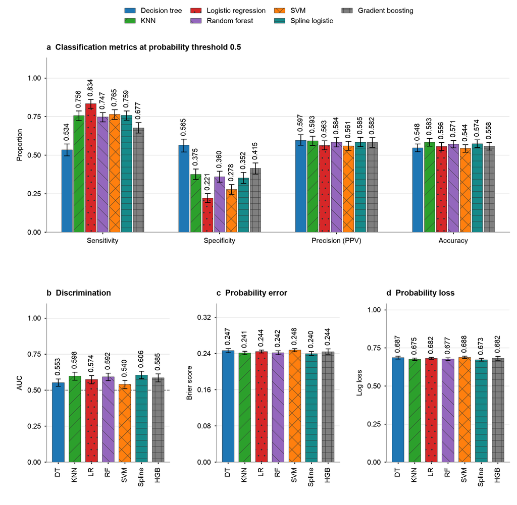

Performance metrics for the seven full-feature algorithms, retaining the grouped-bar presentation of the original manuscript. Panel a shows sensitivity, specificity, precision (positive predictive value) and accuracy at a fixed threshold of 0.5; panels b–d show AUC, Brier score and log loss. All bars start at zero and use survey-weighted held-out predictions. Whiskers are 95% intervals from the same 1,000 stratified rescaled PSU-bootstrap replicates, conditional on trained models and validation folds. All replicates had valid denominators for the displayed metrics. The dashed AUC line denotes chance discrimination. Higher AUC and lower Brier score/log loss indicate better performance. KNN fitting is unweighted, with weighted tuning and evaluation. DT, decision tree; LR, logistic regression; RF, random forest; SVM, support vector machine; HGB, histogram gradient boosting. Nested cross-validation and the conditional bootstrap serve different purposes and are not presented as independent validation experiments.

Table 7. Calibration and additional metrics for the seven full-feature algorithms.

| Algorithm | AUC, unweighted | Average precision | Calibration intercept | Calibration slope | Sensitivity | Specificity | PPV | NPV |
| --- | --- | --- | --- | --- | --- | --- | --- | --- |
| Linear logistic regression | 0.582 | 0.604 | 0.002 | 1.160 | 0.834 | 0.221 | 0.563 | 0.525 |
| Spline logistic regression | 0.617 | 0.641 | 0.002 | 1.167 | 0.759 | 0.352 | 0.585 | 0.548 |
| Random forest | 0.612 | 0.633 | 0.007 | 0.926 | 0.747 | 0.360 | 0.584 | 0.541 |
| Histogram gradient boosting | 0.613 | 0.628 | 0.010 | 0.610 | 0.677 | 0.415 | 0.582 | 0.516 |
| Support vector machine | 0.581 | 0.584 | 0.021 | 0.543 | 0.765 | 0.278 | 0.561 | 0.495 |
| Decision tree | 0.571 | 0.588 | -0.004 | 0.578 | 0.534 | 0.565 | 0.597 | 0.502 |
| K-nearest neighbours | 0.603 | 0.633 | 0.033 | 1.328 | 0.756 | 0.375 | 0.593 | 0.561 |

Only the explicitly labelled AUC column is unweighted; remaining columns use survey weights. Calibration values are point estimates. Threshold-based measures use 0.5 and do not establish clinical utility. Their intervals in the compound figure use the same 1,000 conditional PSU-bootstrap replicates, with valid metric denominators in every replicate. PPV/NPV are positive/negative predictive values.

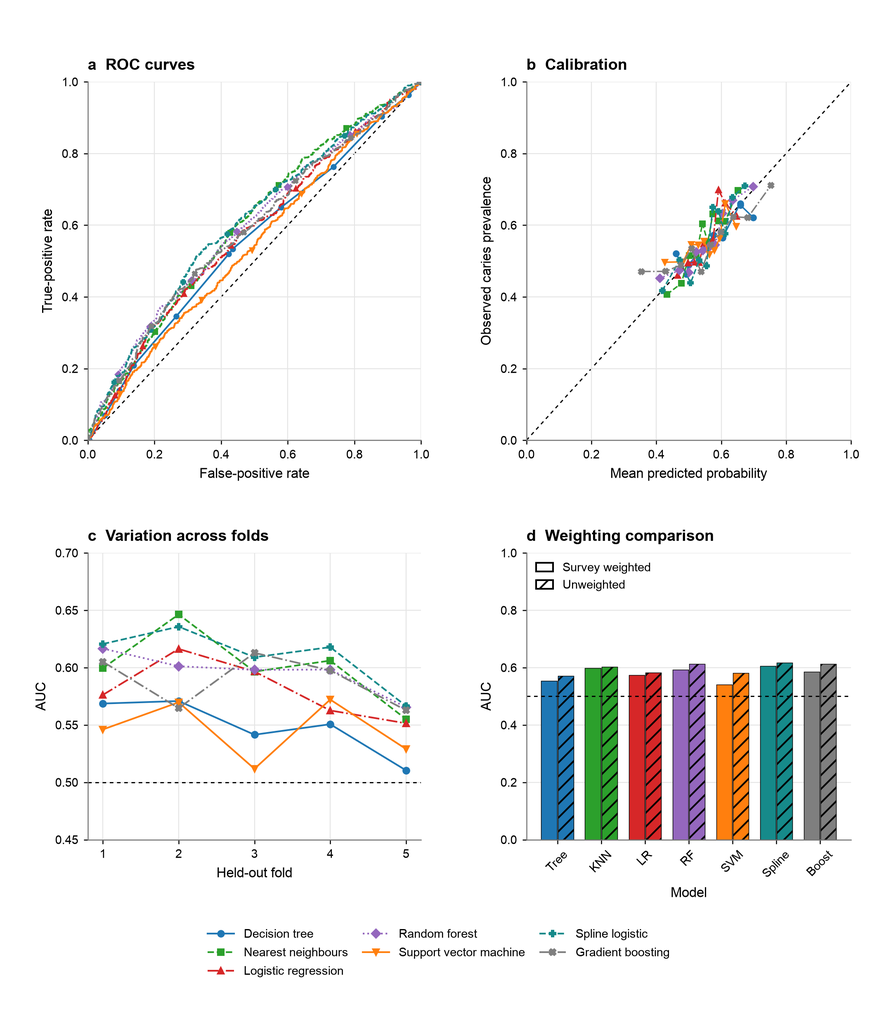

Validation of the seven full-feature algorithms using fixed out-of-fold predictions for 5,036 dentate participants. (a) Survey-weighted ROC curves. (b) Survey-weighted observed prevalence versus mean predicted probability within model-specific quantile bins; lines join bin summaries and are not fitted calibration functions. The diagonal denotes chance discrimination in a and perfect calibration in b. (c) Survey-weighted AUC in each of the five held-out folds; the explicitly labelled local AUC scale applies only to this point-and-line panel. These are descriptive fold estimates, not uncertainty intervals. (d) Pooled survey-weighted and unweighted AUC point estimates on a zero-baseline bar scale. Horizontal dashed lines denote AUC=0.5. No confidence intervals or tests of differences are displayed in this figure. LR, logistic regression; RF, random forest; KNN, nearest neighbours; SVM, support vector machine.

## 6 Contributions and stability of all predictors

All 27 raw predictors are evaluated in held-out folds, retaining the encoded columns of each predictor as a group. Mean increases in weighted Brier score quantify disruption of each fitted classifier; AUC decreases are complementary summaries. Higher positive values indicate greater reliance on that predictor for held-out performance. Negative values mean performance improved after permutation in these evaluations; they do not imply a protective effect. Ranks are compared across folds and model families rather than treated as fixed biological attributes.

Correlation can distribute importance across predictors, and permutation can create unrealistic covariate combinations. These analyses measure model reliance, not a causal effect or the direction of an exposure–outcome association. A predictor can be useful jointly with others while having little individual permutation importance. Conversely, measurable permutation importance does not establish that adding it improves a separately developed model.

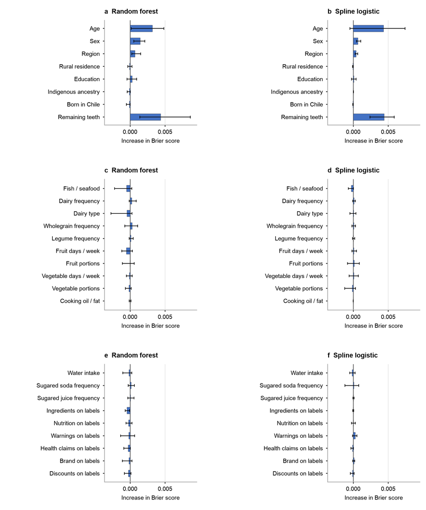

All 27 predictors in random forest and spline logistic regression, retaining the original blue horizontal-bar style. Panels a–b contain eight demographic/dental predictors; c–d contain nine food-intake variables and cooking fat; e–f contain water, sweetened-drink frequencies and six label behaviours. Within each row, both models have the same fixed conceptual order; no variable is selected or omitted on its importance. All six panels use the same numerical axis and zero bar baseline, preserving null and negative results. Bars show mean held-out Brier-score increases after raw-variable permutation. Five repeats are averaged within each fold, then weighted by held-out expansion-weight totals. Whiskers span minimum to maximum fold means, not confidence intervals. Water is shown in the beverage panels regardless of rank. Complete numerical ranks and stability remain in the supplementary tables and Figure S7. Scores are unscaled Brier changes, not the original rescaled importance score; importance is neither causal nor directional.

Table 8. Contributions and fold stability of all 27 predictors.

| Predictor | RF: ΔBrier | RF: AUC drop | RF: median rank (range) | RF: top-three folds | Spline: ΔBrier | Spline: AUC drop | Spline: median rank (range) | Spline: top-three folds |
| --- | --- | --- | --- | --- | --- | --- | --- | --- |
| Remaining teeth | 0.0044 | 0.0333 | 1 (1–3) | 100% | 0.0044 | 0.0377 | 2 (1–2) | 100% |
| Age | 0.0032 | 0.0254 | 2 (1–13) | 80% | 0.0043 | 0.0315 | 1 (1–25) | 80% |
| Sex | 0.0014 | 0.0089 | 3 (2–4) | 60% | 0.0007 | 0.0041 | 3 (3–7) | 60% |
| Region | 0.0007 | 0.0074 | 4 (3–11) | 20% | 0.0004 | 0.0030 | 6 (5–8) | 0% |
| Education | 0.0003 | 0.0035 | 7 (5–25) | 0% | 0.0001 | 0.0012 | 12 (5–25) | 0% |
| Wholegrain frequency | 0.0003 | 0.0007 | 6 (3–26) | 20% | 0.0001 | -0.0005 | 9 (7–23) | 0% |
| Label: warnings | -0.0002 | -0.0006 | 8 (5–26) | 0% | 0.0003 | 0.0007 | 6 (3–26) | 20% |
| Dairy frequency | 0.0002 | 0.0023 | 10 (2–22) | 20% | 0.0001 | 0.0002 | 11 (7–23) | 0% |
| Sweetened soda frequency | 0.0002 | 0.0035 | 13 (4–23) | 0% | 0.0001 | 0.0005 | 10 (2–27) | 20% |
| Fruit portions | -0.0000 | 0.0010 | 11 (5–27) | 0% | 0.0002 | 0.0022 | 4 (3–27) | 20% |
| Legume frequency | 0.0001 | 0.0025 | 13 (5–16) | 0% | 0.0000 | 0.0002 | 14 (11–22) | 0% |
| Label: brand | -0.0002 | -0.0001 | 14 (8–27) | 0% | 0.0001 | 0.0001 | 12 (9–17) | 0% |
| Vegetable days/week | -0.0001 | -0.0006 | 17 (6–26) | 0% | 0.0001 | -0.0001 | 11 (5–26) | 0% |
| Fruit days/week | -0.0006 | -0.0026 | 23 (7–27) | 0% | 0.0001 | -0.0004 | 20 (4–27) | 0% |
| Sweetened juice frequency | 0.0001 | 0.0011 | 11 (6–25) | 0% | 0.0000 | 0.0003 | 14 (11–18) | 0% |
| Dairy type | -0.0005 | -0.0022 | 10 (9–27) | 0% | 0.0000 | -0.0005 | 10 (7–26) | 0% |
| Label: nutrition | -0.0002 | -0.0009 | 20 (9–24) | 0% | 0.0000 | -0.0002 | 13 (8–24) | 0% |
| Label: ingredients | -0.0004 | -0.0026 | 22 (21–25) | 0% | 0.0000 | -0.0003 | 15 (12–20) | 0% |
| Indigenous identification | -0.0001 | -0.0004 | 17 (15–21) | 0% | 0.0000 | 0.0001 | 15 (13–19) | 0% |
| Cooking oil/fat | -0.0000 | -0.0007 | 16 (12–18) | 0% | -0.0000 | -0.0000 | 17 (13–22) | 0% |
| Born in Chile | -0.0001 | -0.0006 | 17 (14–20) | 0% | -0.0000 | -0.0003 | 17 (15–24) | 0% |
| Rural residence | -0.0001 | -0.0004 | 19 (9–22) | 0% | -0.0001 | -0.0004 | 19 (16–21) | 0% |
| Label: discounts | -0.0003 | 0.0000 | 22 (11–23) | 0% | -0.0001 | -0.0002 | 19 (13–25) | 0% |
| Label: health | -0.0003 | -0.0013 | 20 (15–26) | 0% | -0.0001 | -0.0012 | 21 (12–24) | 0% |
| Vegetable portions | -0.0002 | -0.0007 | 17 (12–24) | 0% | -0.0001 | -0.0001 | 10 (7–27) | 0% |
| Water intake | -0.0002 | 0.0004 | 15 (10–24) | 0% | -0.0002 | -0.0013 | 24 (9–26) | 0% |
| Fish/seafood frequency | -0.0005 | -0.0024 | 14 (9–27) | 0% | -0.0003 | -0.0019 | 21 (18–27) | 0% |

RF = random forest; spline = spline logistic regression. ΔBrier and AUC drop are means using held-out expansion-weight totals. Rank ranges are stability summaries, not confidence intervals. Rows are ordered by the larger mean ΔBrier across the two models; this ordering is descriptive. Complete fold ranges are available in the aggregate importance file.

The two top-three lists share **Age, Sex, Remaining teeth**. Agreement between algorithms supports a model-comparison description; disagreement and broad rank ranges indicate dependence on the fitted functional form and training sample. The full table retains low, null and negative contributions, avoiding selection of only the most prominent findings.

### 6.1 Joint contributions of predictor blocks

The conceptual blocks are jointly permuted with the same row permutation for all variables in a block. This preserves relationships within that block while disrupting its relationship to the remaining predictors and outcome. Group importance is not the sum of individual importances, and blocks differ in size. It is also distinct from retraining a model after removing a block. The existing random-forest and spline models are reproduced from their selected parameters, with held-out probabilities checked against the saved values; no new algorithm is added.

Table 9. Joint permutation importance of conceptual predictor blocks.

| Block | Predictors | RF: ΔBrier (fold range) | RF: median rank (range) | Spline: ΔBrier (fold range) | Spline: median rank (range) |
| --- | --- | --- | --- | --- | --- |
| Sociodemographic | 7 | 0.0055 (0.0021 to 0.0093) | 2 (1–2) | 0.0060 (0.0014 to 0.0102) | 1 (1–2) |
| Remaining teeth | 1 | 0.0048 (0.0017 to 0.0072) | 1 (1–2) | 0.0046 (0.0026 to 0.0070) | 2 (1–2) |
| Beverages | 3 | 0.0004 (-0.0001 to 0.0013) | 3 (3–5) | 0.0001 (-0.0006 to 0.0007) | 4 (4–6) |
| Label-related behaviours | 6 | -0.0006 (-0.0021 to 0.0002) | 6 (4–6) | 0.0003 (-0.0008 to 0.0013) | 5 (3–5) |
| Food intake | 9 | -0.0009 (-0.0030 to 0.0000) | 5 (4–6) | 0.0002 (-0.0010 to 0.0011) | 3 (3–6) |
| Cooking fat | 1 | -0.0000 (-0.0002 to 0.0001) | 4 (3–5) | -0.0000 (-0.0000 to 0.0000) | 5 (3–6) |

Blocks are defined for this exploratory follow-up. Fold ranges are descriptive stability intervals, not confidence intervals. Joint disruption preserves within-block relationships; block sizes differ, so values must not be interpreted as per-variable contributions.

**Sociodemographic:** Age, Sex, Region, Rural residence, Education, Indigenous identification, Born in Chile; **Remaining teeth:** Remaining teeth; **Food intake:** Fish/seafood frequency, Dairy frequency, Dairy type, Wholegrain frequency, Legume frequency, Fruit days/week, Fruit portions, Vegetable days/week, Vegetable portions; **Label-related behaviours:** Label: ingredients, Label: nutrition, Label: warnings, Label: health, Label: brand, Label: discounts; **Beverages:** Water intake, Sweetened soda frequency, Sweetened juice frequency; **Cooking fat:** Cooking oil/fat.

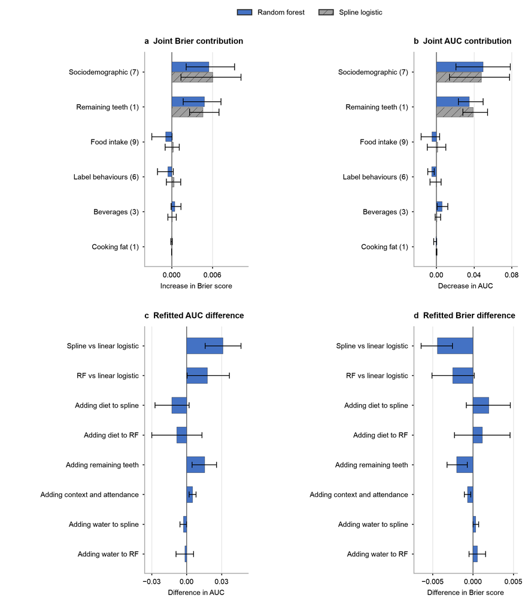

Predictor-family contributions and added value after refitting. Panels a and b show joint held-out permutation of six exhaustive groups, with numbers of predictors in parentheses. Groups were specified after inspection of the initial results. Whiskers span fold-mean ranges, not confidence intervals. Within-group relationships are preserved through joint row permutation. Panels c and d show paired differences after separately redeveloping the specified model variants, with 95% conditional intervals from 1,000 shared stratified PSU-bootstrap replicates. Positive AUC differences and negative Brier-score differences favour the first or expanded model. The contextual extension adds household water supply, recent rural/well/spring water use and dental-attendance recency together. Permutation contributions and refitted comparisons answer different questions and are not interchangeable or causal. Group sizes differ; group contributions are not additive shares of disease explained. All comparisons are exploratory without multiplicity adjustment.

## 7 Comparisons of algorithms and predictor blocks

Table 10. Paired incremental differences on identical participants and folds.

| Comparison | ΔAUC (95% CI) | ΔBrier (95% CI) | Δlog loss (95% CI) |
| --- | --- | --- | --- |
| Random forest versus linear logistic | 0.0178 (0.0005 to 0.0367) | -0.0025 (-0.0051 to 0.0002) | -0.0054 (-0.0109 to 0.0004) |
| Spline versus linear logistic | 0.0311 (0.0159 to 0.0466) | -0.0044 (-0.0064 to -0.0025) | -0.0092 (-0.0133 to -0.0053) |
| Adding water to random forest | -0.0015 (-0.0092 to 0.0059) | 0.0005 (-0.0005 to 0.0016) | 0.0013 (-0.0009 to 0.0033) |
| Adding water to spline logistic | -0.0028 (-0.0059 to 0.0000) | 0.0003 (-0.0000 to 0.0007) | 0.0007 (-0.0000 to 0.0014) |
| Adding dietary variables to random forest | -0.0085 (-0.0301 to 0.0131) | 0.0012 (-0.0023 to 0.0046) | 0.0018 (-0.0054 to 0.0090) |
| Adding dietary variables to spline logistic | -0.0127 (-0.0272 to 0.0020) | 0.0020 (-0.0008 to 0.0046) | 0.0040 (-0.0018 to 0.0097) |
| Adding water context and dental attendance | 0.0049 (0.0021 to 0.0080) | -0.0007 (-0.0011 to -0.0003) | -0.0014 (-0.0022 to -0.0006) |
| Adding remaining teeth | 0.0155 (0.0047 to 0.0256) | -0.0020 (-0.0032 to -0.0007) | -0.0043 (-0.0067 to -0.0016) |

Difference = first model minus reference. Positive AUC differences favour the first model; negative Brier/log-loss differences favour it. These separately developed model contrasts differ from joint permutation of fixed fitted models. All are exploratory, including the water follow-ups; intervals are conditional and unadjusted for multiple comparisons.

For **model flexibility**, spline versus linear logistic regression gives ΔAUC 0.0311 (0.0159 to 0.0466); the conditional interval favours the first model. Random forest versus linear logistic gives ΔAUC 0.0178 (0.0005 to 0.0367); the conditional interval favours the first model. The probability-score contrasts in Table 10 provide a separate check against interpreting ranking gains alone as improvement in predicted probabilities.

Adding the **entire dietary block** to spline regression gives ΔAUC -0.0127 (-0.0272 to 0.0020). Adding **water context and dental attendance** gives ΔAUC 0.0049 (0.0021 to 0.0080); the conditional interval favours the first model. The extension changes three variables together, so its difference cannot be assigned to water source alone. Adding **remaining teeth** gives ΔAUC 0.0155 (0.0047 to 0.0256); this concurrent clinical measurement should be considered when defining any intended future use.

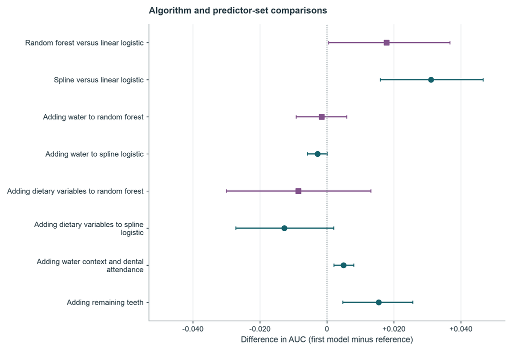

Paired differences in survey-weighted out-of-fold AUC, with 95% conditional stratified PSU-bootstrap intervals. Each contrast subtracts the reference model from the first model. Positive differences favour the first model. Markers and colours identify the first model's algorithm family: teal circles for spline logistic regression, purple squares for random forest, and grey diamonds for other algorithms. Validation participants and bootstrap draws are shared within each pair; models and the validation split remain fixed.

## 8 Subgroups and robustness

The six-panel sensitivity figure combines population restrictions and subgroup point estimates with a controlled examination of water encoding. The encoding comparison was added after reviewing the historical scripts and uses the original physical-model hyperparameters, identical outer folds, weights and seeds. Four alternative variants require 20 additional outer fits; the two physical-reference models and their predictions are reused. There is no new hyperparameter search. Nominal categories retain each observed intake as a separate level; they are not low/medium/high groups. The historical index lookup is a fixed, data-derived artifact from the original dentate data, while imputation, scaling, knots and the nominal vocabulary are learned within outer training samples.

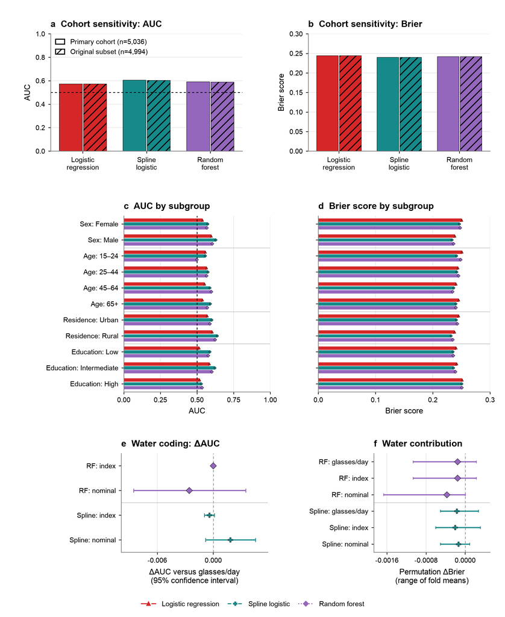

Exploratory sensitivity analyses. (a,b) Weighted AUC and Brier scores in the primary cohort (n=5,036) and overlapping original subset (n=4,994), using identical held-out predictions. (c,d) Corresponding subgroup point estimates, without intervals or heterogeneity tests. (e) Paired ΔAUC for historical-index or nominal water coding versus reported glasses/day, with conditional 95% stratified PSU-bootstrap intervals. (f) Water’s mean held-out ΔBrier under all three codings in RF and spline logistic regression; whiskers span five fold means and are not confidence intervals. Encoding sensitivities retain selected parameters. Higher AUC and lower Brier favour performance; positive permutation ΔBrier indicates contribution. RF, random forest.

Table 11. Exploratory subgroup performance for three central comparisons.

| Grouping | Level | n | Linear: AUC / Brier | Spline: AUC / Brier | RF: AUC / Brier |
| --- | --- | --- | --- | --- | --- |
| Sex | Female | 3,125 | 0.537 / 0.250 | 0.572 / 0.246 | 0.567 / 0.248 |
| Sex | Male | 1,911 | 0.596 / 0.238 | 0.628 / 0.233 | 0.603 / 0.236 |
| Age group | 15–24 | 729 | 0.557 / 0.251 | 0.556 / 0.242 | 0.497 / 0.249 |
| Age group | 25–44 | 1,569 | 0.564 / 0.244 | 0.575 / 0.242 | 0.564 / 0.245 |
| Age group | 45–64 | 1,759 | 0.552 / 0.241 | 0.587 / 0.236 | 0.597 / 0.234 |
| Age group | 65+ | 979 | 0.536 / 0.245 | 0.591 / 0.240 | 0.569 / 0.240 |
| Education | High | 1,179 | 0.517 / 0.251 | 0.529 / 0.251 | 0.534 / 0.250 |
| Education | Intermediate | 2,811 | 0.584 / 0.242 | 0.621 / 0.236 | 0.601 / 0.239 |
| Education | Low | 1,008 | 0.515 / 0.241 | 0.588 / 0.235 | 0.576 / 0.235 |
| Rural | Rural | 760 | 0.603 / 0.238 | 0.638 / 0.232 | 0.623 / 0.235 |
| Rural | Urban | 4,276 | 0.570 / 0.245 | 0.601 / 0.241 | 0.588 / 0.243 |

These weighted point estimates reuse the full-cohort held-out predictions. They have no subgroup-specific confidence intervals or formal interaction tests; apparent ranking differences are not established heterogeneity.

Table 12. Evaluation on the manuscript subset and participants aged at least 18.

| Subset | Model | n | AUC | Brier | Calibration intercept | Calibration slope |
| --- | --- | --- | --- | --- | --- | --- |
| Exact manuscript subset | Linear logistic regression | 4,994 | 0.573 | 0.244 | 0.002 | 1.145 |
| Age at least 18 | Linear logistic regression | 4,822 | 0.568 | 0.244 | 0.047 | 1.047 |
| Exact manuscript subset | Spline logistic regression | 4,994 | 0.604 | 0.240 | 0.003 | 1.156 |
| Age at least 18 | Spline logistic regression | 4,822 | 0.596 | 0.240 | 0.024 | 1.120 |
| Exact manuscript subset | Random forest | 4,994 | 0.591 | 0.242 | 0.007 | 0.911 |
| Age at least 18 | Random forest | 4,822 | 0.587 | 0.241 | 0.034 | 0.897 |

These analyses restrict existing out-of-fold predictions. The manuscript subset is not a newly developed complete-case model; training retains the primary imputation-based strategy. Association-model sample sizes differ because their covariate completeness rules differ.

## 9 Implications for the manuscript

The manuscript should lead with the contributions of all demographic, dental and dietary predictors to current caries classification. Present both model families, all 27 predictor results and their fold stability, alongside the joint block analyses. Calibration, probability scores and discrimination establish the performance context in which those contributions were measured. A prominent importance rank is a hypothesis-generating finding, not evidence of causation or a reason to make one exposure the study’s original objective.

Claims of general algorithm superiority should be tied to the actual comparisons. A small AUC improvement over a linear model does not establish clinically useful discrimination, and a full dietary model need not outperform a simpler demographic/dental model. Correlated predictors and unequal block sizes limit direct attribution. Findings such as water can motivate explicitly secondary analyses; their selection after observing results must remain transparent. No finding here supports a clinical recommendation to increase water intake to prevent caries.

This emphasis is consistent with the distinction between diagnostic and prognostic models, appropriate validation and practical usefulness discussed in the [Caries Research methodological review](https://karger.com/cre/article/doi/10.1159/000553309/952744/Prognostic-Clinical-Predictive-Models-for-Dental). Transparent descriptions of population, missingness, model development and performance also follow the reporting aims of [TRIPOD+AI](https://doi.org/10.1136/bmj-2023-078378). Neither reference substitutes for evaluation of this dataset or guarantees journal acceptance.

The main limitations are cross-sectional temporality; self-reported predictors, exposure tails and measurement error; selection into the examination and dentate domains; the working, incompletely documented weight choice; singleton-variance conventions; and reliance on a concurrent tooth-count predictor. Importance depends on the fitted model, correlations and the perturbation scheme. The dataset-informed grid amendment, later block analysis and multiple exploratory comparisons add development uncertainty; permutation stability ranges and conditional metric intervals do not cover all of it. There is no temporal or geographic external validation, no assessment of clinical net benefit, and no demonstrated transportability or deployment readiness. The water follow-up additionally lacks measured fluoride exposure, a verified glass volume and temporal ordering.

## 10 Supplementary exploratory follow-up: water

Water was an emerging finding considered after inspecting predictor results, rather than the primary scientific objective. The analyses below assess that finding’s adjusted association and sensitivity to assumptions. Their placement and interpretation preserve this exploratory status.

### 10.1 Historical coding and controlled representation sensitivity

Water-encoding supplement A. Six variants under fixed hyperparameters.

| Model | Water representation | AUC (95% CI) | Brier (95% CI) | Log loss (95% CI) |
| --- | --- | --- | --- | --- |
| Random forest | Reported glasses/day | 0.592 (0.565 to 0.618) | 0.242 (0.237 to 0.246) | 0.677 (0.667 to 0.686) |
| Random forest | Historical factor index | 0.592 (0.565 to 0.618) | 0.242 (0.237 to 0.246) | 0.677 (0.667 to 0.686) |
| Random forest | Nominal water categories | 0.590 (0.563 to 0.616) | 0.242 (0.237 to 0.247) | 0.677 (0.667 to 0.686) |
| Spline logistic regression | Reported glasses/day | 0.606 (0.579 to 0.632) | 0.240 (0.236 to 0.244) | 0.673 (0.664 to 0.682) |
| Spline logistic regression | Historical factor index | 0.605 (0.579 to 0.631) | 0.240 (0.236 to 0.245) | 0.673 (0.664 to 0.682) |
| Spline logistic regression | Nominal water categories | 0.607 (0.581 to 0.634) | 0.240 (0.236 to 0.244) | 0.672 (0.664 to 0.681) |

Physical references use reported glasses/day; historical indices code ordered individual quantities; nominal categories use one-hot encoding. Physical models are unchanged. These are controlled representation sensitivities, not independently tuned model comparisons or exact reconstructions of R factor handling.

Water-encoding supplement B. Paired differences versus reported glasses/day.

| Model | Water representation | ΔAUC (95% CI) | ΔBrier (95% CI) | Δlog loss (95% CI) |
| --- | --- | --- | --- | --- |
| Random forest | Historical factor index | 0.0000 (0.0000 to 0.0000) | 0.0000 (-0.0000 to 0.0000) | 0.0000 (-0.0000 to 0.0000) |
| Random forest | Nominal water categories | -0.0026 (-0.0086 to 0.0035) | 0.0001 (-0.0008 to 0.0009) | 0.0001 (-0.0017 to 0.0019) |
| Spline logistic regression | Historical factor index | -0.0004 (-0.0010 to 0.0001) | 0.0001 (0.0000 to 0.0001) | 0.0001 (0.0000 to 0.0003) |
| Spline logistic regression | Nominal water categories | 0.0018 (-0.0008 to 0.0045) | -0.0002 (-0.0005 to 0.0001) | -0.0004 (-0.0011 to 0.0003) |

Positive ΔAUC and negative probability-score differences favour the alternative. Intervals use 1,000 shared rescaled PSU draws and hold fits and folds fixed. A point and interval at zero can result from identical predictions; this is not a missing uncertainty estimate.

Random forest gives AUC **0.592248** with reported glasses/day and **0.592248** with historical indices (paired ΔAUC 0.000000). The two probability sets agree to numerical precision in this run. Thus, changing the index representation to physical units does not explain the earlier prominence of water in this fitted random forest. All four paired AUC intervals include zero; this does not establish equivalence. The comparison changes representation under fixed settings, and cannot isolate the effects of historical importance metrics, weighting, sample selection or validation design.

Water-encoding supplement C. Held-out water permutation importance.

| Model | Water representation | Mean ΔBrier | Five-fold range |
| --- | --- | --- | --- |
| Random forest | Reported glasses/day | -0.000156 | -0.001065 to 0.000229 |
| Random forest | Historical factor index | -0.000156 | -0.001065 to 0.000229 |
| Random forest | Nominal water categories | -0.000378 | -0.001669 to 0.000002 |
| Spline logistic regression | Reported glasses/day | -0.000173 | -0.000506 to 0.000270 |
| Spline logistic regression | Historical factor index | -0.000206 | -0.000605 to 0.000311 |
| Spline logistic regression | Nominal water categories | -0.000136 | -0.000508 to 0.000091 |

Five shared donor-row permutations per outer fold include missing water values. Ranges summarize fold stability and are not confidence intervals. Only water is permuted in the alternative encodings, so no new global predictor ranks are inferred. One-hot dimensionality may also alter random-forest feature subsampling under fixed settings.

## 11 Matched comparison using the original paper coding

The reconstructed historical matrix contains 90 columns for 27 predictors in the original 4,994 complete cases. An independent R preprocessing export agrees with the recovered processed-data cache; the production reconstruction and new model fits use Python. The historical representation uses water level indices, fruit/vegetable-day categories with treatment contrasts, original weekly beverage frequencies with four-week months, and the original category reference levels. The current representation retains physical quantities, numerical days and training-fitted one-hot encoding.

Both random-forest variants are newly trained in the same complete cases. They inherit the same five PSU-disjoint outer assignments, weights, seeds and per-fold hyperparameters from the principal forest’s outer training data. No new tuning occurs; selection originally used the larger cohort’s training portion. This compares the representation package while holding the cohort fixed. It is distinct from the earlier complete-case evaluation of models trained in 5,036 participants and from the water-only sensitivity. It does not recreate the original caret engine or participant-level split.

Historical coding supplement A. Matched random-forest refits.

| Representation | n | AUC (95% CI) | Brier score | Log loss |
| --- | --- | --- | --- | --- |
| Historical coding, complete-case refit | 4,994 | 0.5912 (0.5622 to 0.6180) | 0.241691 | 0.676122 |
| Modern coding, complete-case refit | 4,994 | 0.5911 (0.5633 to 0.6184) | 0.241842 | 0.676459 |

Both models are trained and evaluated in the same 4,994 participants. Intervals are conditional PSU-bootstrap intervals for fixed models and inherited folds.

Historical coding supplement B. Paired performance differences.

| Metric | Historical minus modern | Conditional 95% CI |
| --- | --- | --- |
| auc | 0.000094 | -0.008893 to 0.008709 |
| brier | -0.000151 | -0.001468 to 0.001090 |
| log_loss | -0.000336 | -0.003075 to 0.002178 |

Positive AUC differences and negative Brier/log-loss differences favour the historical representation. Comparisons are exploratory and do not isolate water from the other coding differences.

Historical coding supplement C. Water within the complete 27-predictor comparison.

| Representation | Mean water ΔBrier | Five-fold range |
| --- | --- | --- |
| Historical coding, complete-case refit | -0.000362 | -0.001233 to 0.000013 |
| Modern coding, complete-case refit | -0.000121 | -0.000505 to 0.000172 |

Each predictor is permuted jointly across its encoded columns using five shared row permutations per held-out fold. Negative values are retained; fold ranges are not confidence intervals.

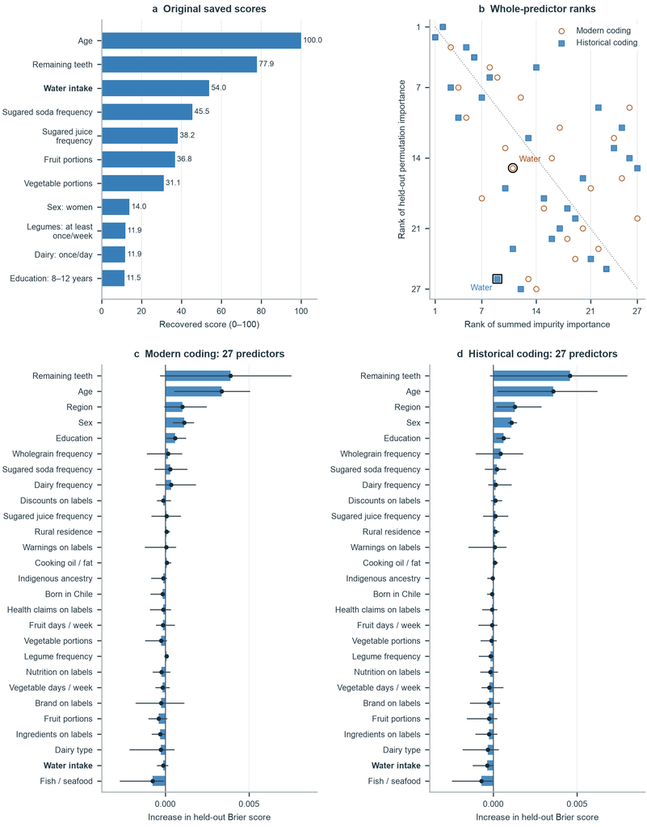

Historical coding and the unit of predictor importance. a, the 11 recovered original chart scores, with the legume category corrected to at least once/week; these saved scores are a separate historical result, not an exact refit. b, ranks of summed impurity importance versus whole-predictor held-out permutation importance in each new forest variant; smaller ranks indicate larger contributions. Summing impurity scores is not permutation importance. c–d, all 27 mean permutation contributions, with a common order and axis; whiskers are the five-fold minimum–maximum, not confidence intervals. Both variants are newly trained in the same 4,994 complete cases with the same inherited PSU-disjoint folds, weights and per-fold parameters selected in the principal forest's outer training data; no retuning occurs. Historical coding jointly changes water indices, fruit/vegetable-day factors, beverage units and categorical contrasts. Results evaluate this representation package, not each component separately or the original caret workflow.

The new impurity scores are calculated on the fitted forests, both per column and summed within each original predictor. Those sums remain impurity scores. Held-out permutation instead measures predictive deterioration after perturbing the whole predictor while preserving its category combinations. The recovered 0–100 chart is shown as a separate historical reference, with its legume-category translation corrected; none of the new fits is asserted to reproduce its scores exactly. [Permutation and impurity importance](https://scikit-learn.org/stable/modules/permutation_importance.html).

## 12 Exploratory water associations

Eight survey-weighted association analyses separate effect estimation from algorithm comparison. The primary logistic model estimates a linear water term while adjusting flexibly for age, remaining teeth and soda/juice frequency, plus sex, region, rurality, education, indigenous identification and birthplace. A second model uses a water spline. Further analyses add the three contextual variables, restrict age, assess the exposure tail, omit remaining teeth, estimate a modified Poisson prevalence ratio, or retain the original 28-day beverage conversion. The last analysis was added after source reconciliation. These regressions use complete required covariates, rather than the prediction pipeline’s imputation strategy.

For the exploratory **water** comparison, the spline comparison gives ΔAUC -0.0028 (-0.0059 to 0.0000); the conditional interval includes no difference. The random-forest comparison gives ΔAUC -0.0015 (-0.0092 to 0.0059); the conditional interval includes no difference. A predictor can have permutation importance while adding little beyond correlated variables. Importance ranking is therefore insufficient evidence of incremental usefulness.

Table 13. Adjusted cross-sectional water associations and sensitivity analyses.

| Analysis | n | Measure | Estimate (95% CI) | p value |
| --- | --- | --- | --- | --- |
| Primary linear water | 4,994 | Odds ratio | 0.988 (0.957 to 1.019) | 0.427 |
| Water spline: 6 versus 2 reported glasses/day | 4,994 | Conditional odds ratio | 0.905 (0.684 to 1.197) | 0.484 |
| Additional water context and dental attendance | 4,987 | Odds ratio | 0.987 (0.957 to 1.018) | 0.414 |
| Age at least 18 | 4,780 | Odds ratio | 0.985 (0.954 to 1.017) | 0.341 |
| Exclude water above 99th percentile | 4,962 | Odds ratio | 0.976 (0.942 to 1.012) | 0.185 |
| Without remaining teeth | 4,994 | Odds ratio | 0.987 (0.958 to 1.017) | 0.386 |
| Modified Poisson prevalence ratio | 4,994 | Prevalence ratio | 0.995 (0.982 to 1.008) | 0.432 |
| Original 28-day beverage conversion | 4,994 | Odds ratio | 0.988 (0.957 to 1.019) | 0.427 |

All linear estimates compare one additional reported glass/day. The spline row is a conditional odds ratio at identical other covariates. Odds ratios and prevalence ratios are different measures; p values are exploratory and unadjusted for multiplicity.

The primary adjusted odds ratio was **0.988 (0.957 to 1.019) per reported glass/day**. The interval includes no association and remains compatible with modest associations in either direction. The spline comparison of 6 versus 2 glasses/day was **0.905 (0.684 to 1.197)**, supported by 408 and 729 participants at those exact intakes, respectively. This contrast is an odds ratio at the same other covariates, not a ratio of standardized prevalences.

The original monthly convention changes daily-equivalent soda frequency for 520 dentate participants and juice frequency for 286. Retaining those original frequencies gives a water odds ratio of **0.988 (0.957 to 1.019)** in 4,994 participants. This sensitivity changes the association adjustment only; the primary nested prediction models retain the declared 30-day convention.

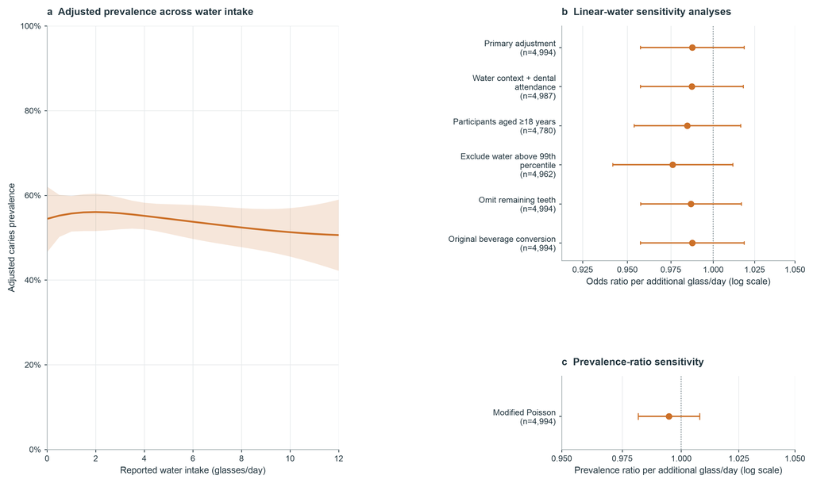

Adjusted cross-sectional association of reported water intake with cavitated caries. Panel a is survey-weighted marginal standardization of the water-spline model, with 95% pointwise delta-method confidence intervals; the displayed exposure grid is restricted to the range supplied in water_curve.csv. Panels b and c show linear-water sensitivity estimates per additional reported glass/day and survey-design 95% intervals. Odds ratios and prevalence ratios are displayed separately on logarithmic axes; the vertical line denotes no association. These estimates do not establish causal protection.

The adjusted curve averages spline-model predictions over the observed covariate distribution using survey weights. Its pointwise delta-method intervals propagate design-based coefficient uncertainty **conditional on that fixed covariate composition**; they do not include uncertainty in the composition itself. The modified Poisson model produced **15 fitted values above one**. Its robust prevalence-ratio coefficient is reported as a sensitivity analysis; those fitted values must not be presented as valid individual probabilities.

## 13 Complete graphical detail

These complementary displays retain all 27 predictors and provide the participant flow and detailed analytical presentation used during development. Their fold ranges are stability summaries, not confidence intervals.

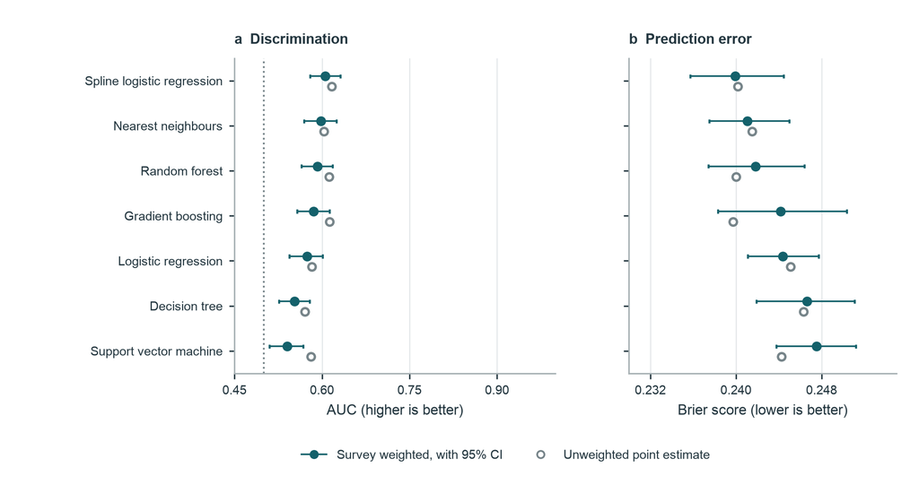

Out-of-fold discrimination and Brier scores for the seven full-feature algorithms. Survey-weighted points have 95% conditional stratified PSU-bootstrap intervals; trained models and validation splits are held fixed. Open points are unweighted estimates. AUC=0.5 denotes chance discrimination. The Brier-score dot plot uses an explicitly labelled local scale covering all intervals and point estimates. Models are ordered by weighted AUC.

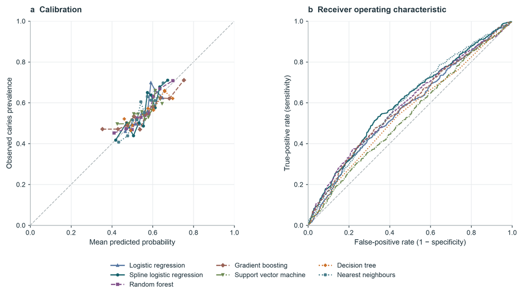

Survey-weighted calibration and ROC curves from out-of-fold predictions for the full-feature algorithms. Calibration points represent quantile-based groups of predicted probability; the diagonal indicates perfect calibration. The ROC diagonal indicates chance discrimination. Binned calibration curves are descriptive and have no confidence intervals.

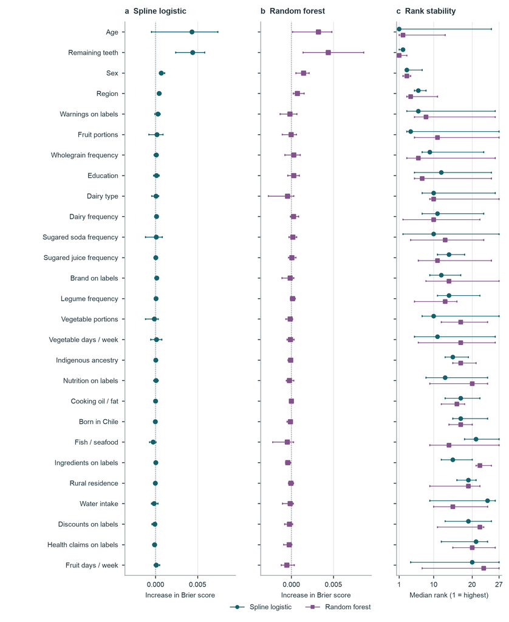

Contributions of all 27 raw held-out predictors, without predictor-specific selection or colour. The two model panels share the same Brier-score scale. Points are mean increases in survey-weighted Brier score after permutation, averaged within each fold over repeats and then across folds using test-set expansion-weight totals. Whiskers show the minimum to maximum fold means; they are stability ranges, not confidence intervals. The final panel displays median within-fold ranks and best-to-worst rank ranges; rank 1 denotes the largest fold-mean Brier increase, with ties assigned the minimum rank. Row order follows the median of the model-specific median ranks. Teal circles denote spline logistic regression and purple squares denote random forest. Negative and null contributions are retained. Importance has no direction or causal interpretation and can be shared among correlated predictors.

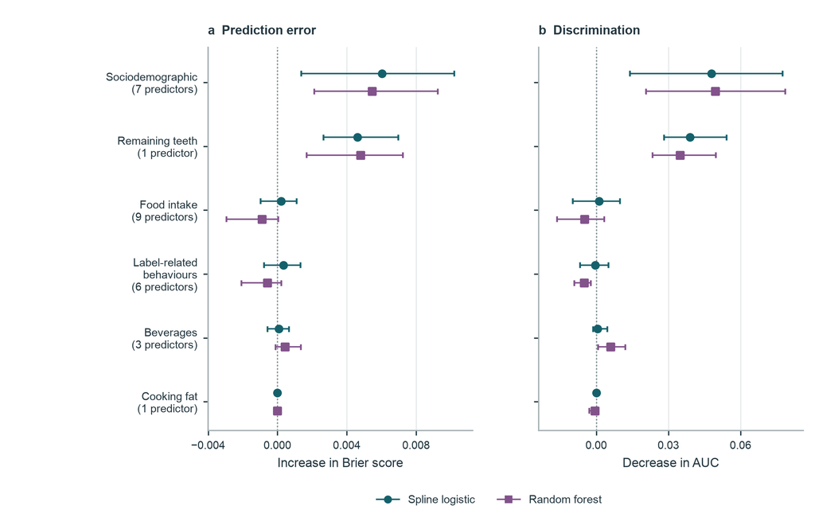

Contributions of six exhaustive predictor groups specified after inspection of the initial model results under joint held-out permutation. The same row permutation is applied to every column within a group, preserving associations among its variables while disrupting that group's relationship with the outcome and other groups. Points are survey-weighted mean Brier-score increases and AUC decreases, summarized over five permutation repeats within each fold and weighted across folds by their test-set expansion-weight totals. Whiskers span the minimum to maximum fold means; these stability ranges are not confidence intervals. Each metric uses a common axis for both models. Negative contributions remain visible. Group importances are not sums of individual importances and are not additive causal effects. Teal circles identify spline logistic regression; purple squares identify random forest.

## 14 Reproducibility and aggregate outputs

The report executes Python against completed aggregate results and stops if required inputs, source hashes, verified reconciliation, cohort checks or the final model grid are inconsistent. Model development and statistical inference are performed by the repository’s analysis pipeline; rendering this document does not retrain models. The recovered Stata source remains intact. Participant-level data, held-out predictions and serialized estimators are excluded from this report. All displayed estimates and figures are read from the completed run.

Table 14. Reproducibility record.

| Item | Recorded value |
| --- | --- |
| Run status | complete |
| Completed (UTC) | 2026-09-10T18:40:25.678797+00:00 |
| Analysis seed | 20260910 |
| Outer / inner folds | 5 / 3 |
| Bootstrap replicates | 1,000 |
| Permutation repeats per predictor/fold | 5 |
| Predictor-contribution analysis | complete |
| Water-encoding sensitivity | complete |
| Alternative water-encoding outer fits / new tuning searches | 20 / 0 |
| Joint-permutation seed / repeats | 20260910 / 5 |
| Largest reproduced-probability difference | 3.3e-16 |
| Log-probability epsilon | 1e-07 |
| Python | 3.14.3 |
| Original Stata source | 23.07.26_base_ens_5520_R_enviar.dta |
| Original Stata SHA-256 | 754c2d32bafd002b861221d9d468f74a703de4ea9dd6c492cf848f042f3b0966 |
| Supplementary SPSS SHA-256 | 9873b421d446190070bfff6495321fb152485c47457692936dbcd18c542eb89a |
| Source reconciliation | verified |
| Original R reference commit | 77c107feb56d3f825cd4ad26354b672f8bfebe38 |
| Supplied stratum / cluster overlap violations | 0 |
| Statistically imputed outcomes | 0 |
| Clipped extreme observations | 0 |

Hashes identify both input releases without exposing participant records or private filesystem locations. The original R reference is linked in the provenance section. Fold overlap checks assess shared PSUs across train/test partitions.

Table 15. Recorded software versions.

| Package | Version |
| --- | --- |
| matplotlib | 3.11.1 |
| numpy | 2.5.3 |
| pandas | 3.0.5 |
| patsy | 1.0.3 |
| pyreadstat | 1.3.6 |
| scikit-learn | 1.9.0 |
| scipy | 1.18.1 |
| statsmodels | 0.15.0 |

Table 16. Association-model diagnostics.

| Association analysis | n | Design df | Rank | Parameters | Converged | Fitted values >1 |
| --- | --- | --- | --- | --- | --- | --- |
| Primary linear water | 4994 | 1045 | 36 | 36 | True | 0 |
| Water spline | 4994 | 1045 | 39 | 39 | True | 0 |
| Additional water context and dental attendance | 4987 | 1045 | 43 | 43 | True | 0 |
| Age at least 18 | 4780 | 1045 | 36 | 36 | True | 0 |
| Exclude water above 99th percentile | 4962 | 1045 | 36 | 36 | True | 0 |
| Without remaining teeth | 4994 | 1045 | 32 | 32 | True | 0 |
| Modified Poisson prevalence ratio | 4994 | 1045 | 36 | 36 | True | 15 |
| Original 28-day beverage conversion | 4994 | 1045 | 36 | 36 | True | 0 |

Convergence and full rank are necessary numerical checks; they do not validate causal assumptions or exposure measurement. The Poisson diagnostic is discussed in the association section.

The standalone HTML embeds its figures. The following links provide repository-local aggregate supplements:

- Population flow, weighted prevalence and predictor dictionary.
- All predictor distributions by caries status and descriptive variance definitions.
- Water-encoding performance, paired encoding comparisons, water importance by encoding and encoding methods.
- Verified source reconciliation, construct comparisons, original water-index mapping and R-to-Python migration audit.
- All model metrics, paired comparisons and internal tuning results.
- Water effects, spline contrast and association diagnostics.
- Subgroup estimates, subset sensitivity and importance stability.
- Raw joint permutations, group stability and predictor-contribution manifest.
- Validation split checks, run manifest, analysis plan and methodological source audit.